# Grass in California : Phytolith analysis

Steve Fick

07 September, 2015

# Intro

It has been traditionally assumed that prior to European colonization, California grasslands were dominated by native, perennial bunch-grasses (clements). As a result, most ecological restoration in these areas, which are now dominated by annual exotic grasses and forbs, has focused on (re)introducing a native perennial grass component to these communities. New evidence from soil phytoliths records (silcate deposits generated over millenia by grasses) and re-evaluations of historical accounts have called this fundamental assumption into question. It has been hypothesized that perhaps perrenial bunchgrasses composed a minor component of pre-columbian communities, if at all.

Using a published dataset of phytolith assemblages across the state (a proxy for pre-historic grass abundance) here I attempt to model the pre-columbian distribution of native grasses. For predictors, I am using downscaled late holocene projections from global climate models (GCMs), elevation and soil characteristics.

## The dataset

Data is from:

> Evett, Rand R., and James W. Bartolome. “Phytolith evidence for the extent and nature of prehistoric Californian grasslands.” The Holocene 23.11 (2013): 1644-1649.

Heres a look at the table …

```
##        id                     series          county    series_area
##  Min.   :  1.00   Nacimiento (31):  3   Tehama   :17   Min.   :  1872
##  1st Qu.: 36.75   Altamont (21)  :  2   Merced   :15   1st Qu.: 19060
##  Median : 78.50   Capay (22)     :  2   Riverside:11   Median : 43250
##  Mean   : 78.03   Columbia (30)  :  2   Butte    : 8   Mean   : 53616
##  3rd Qu.:118.25   Diablo (32)    :  2   Monterey : 7   3rd Qu.: 80861
##  Max.   :153.00   Elkhorn (2)    :  2   Colusa   : 5   Max.   :202814
##                   (Other)        :107   (Other)  :57
##  phyto_content     rondel_cells    bilobate_cells   total_short_cells
##  Min.   :0.0000   Min.   :  0.00   Min.   :  0.00   Min.   :  0.0
##  1st Qu.:0.0400   1st Qu.:  7.00   1st Qu.:  0.00   1st Qu.: 14.0
##  Median :0.0800   Median : 21.00   Median :  0.50   Median : 42.5
##  Mean   :0.1643   Mean   : 51.70   Mean   : 15.85   Mean   :106.2
##  3rd Qu.:0.1700   3rd Qu.: 54.25   3rd Qu.: 10.00   3rd Qu.:109.8
##  Max.   :1.1100   Max.   :347.00   Max.   :425.00   Max.   :783.0
##
##   total_phyto      bilob_ratio Stipa_Danth_dominant      elev
##  Min.   :   5.0   0.00   :60   Mode :logical        Min.   :   2.0
##  1st Qu.:  46.0   0.04   : 8   FALSE:112            1st Qu.:  52.5
##  Median : 125.5   0.01   : 7   TRUE :8              Median : 105.5
##  Mean   : 274.5   0.02   : 6   NA's :0              Mean   : 196.6
##  3rd Qu.: 313.0   0.03   : 6                        3rd Qu.: 243.8
##  Max.   :1338.0   0.09   : 6                        Max.   :1072.0
##                   (Other):27
##    grass          y
##  FALSE:96   Min.   :-4.6052
##  TRUE :24   1st Qu.:-3.2189
##             Median :-2.5257
##             Mean   :-2.4813
##             3rd Qu.:-1.7720
##             Max.   : 0.1044
##
```

### Some Definitions

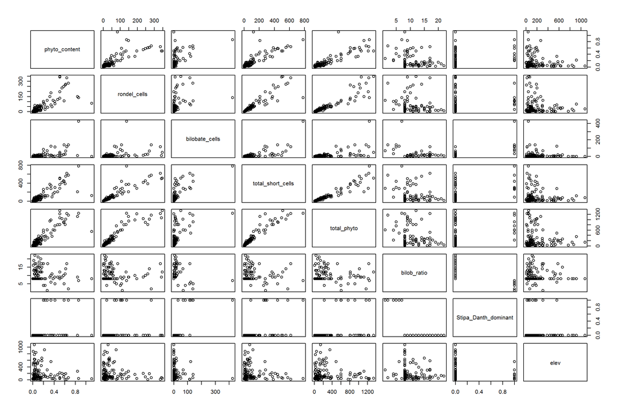

### visualizing

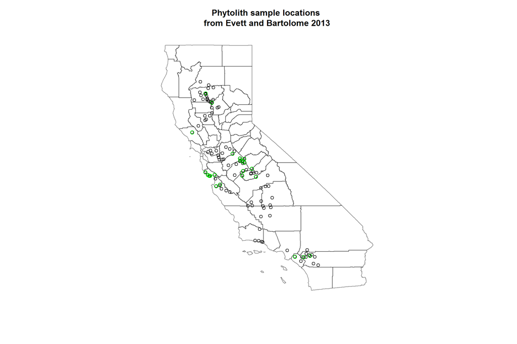

green circles indicate locations where phytolith content surpasses the .3 percent threshold mentioned in the text, indicating a high likelihood of substantial grass presence. Notice that most of the samples do not meet this criteria.  
n = 120

# Modeling

Several model formulations and modeling methods were tried.  
Modeling methods included:

- Ordinary Least Squares (OLS/GLM), with step-wise backward selection using AIC
- Random Forest
- Classification and Regression Trees
- An ensemble model, including previous methods as well as ridge regression and lasso regression

For each method, 3 model formulations were explored : one using current climate data, one using downscaled [CCSM](https://www.ucar.edu/communications/CCSM/) climate projections for 400 AD, and one using mid-holocene projections (~6000 bp). Total Phytolith content was modeled as a function of climate, elevation, and linear distance from coast. Additionally, soil variables including Soil Carbon, clay, sand, silt, CEC, bulk density, coarse fragment, and pH were included as predictors in the models to see if they improved fit. Soil data was extracted from the [ISRIC 1-km resolution soilgrids](http://soilgrids.org/) dataset.

## Model Evaluation

Here are the results of 5-fold cross validation, including correlation,

```
##                     cor      SSE      MSE     RMSE           ME       MAE
## OLS.curent    0.5019660 126.5515 1.054595 1.026935 -0.016259245 0.7964269
## OLS.400AD     0.4493460 135.7382 1.131152 1.063556 -0.019295932 0.8292134
## OLS.6kbp      0.4026001 150.2656 1.252214 1.119023 -0.046822432 0.8385469
## OLS.soil.cur  0.5090700 125.7163 1.047635 1.023541 -0.015325255 0.7952932
## OLS.soil.400  0.4781196 133.2196 1.110163 1.053643 -0.009465007 0.8128955
## OLS.soil.6kbp 0.4716651 137.9241 1.149368 1.072086 -0.027643704 0.8275626
## RF.cur        0.3528235 151.8260 1.265216 1.124818  0.054480361 0.8729286
## RF.400AD      0.3148201 157.1607 1.309672 1.144409  0.026839208 0.8922161
## RF.6kbp       0.3275858 155.1730 1.293108 1.137149  0.043422128 0.8834644
## RF.soil.cur   0.3724708 145.4283 1.211902 1.100864  0.036273351 0.8620859
## RF.soil.400AD 0.3610959 147.2443 1.227036 1.107716  0.027175798 0.8661654
## RF.soil.6kbp  0.3674994 146.0349 1.216958 1.103158  0.043225198 0.8621558
##               moran lower moran upper
## OLS.curent          0.131       0.860
## OLS.400AD           0.225       0.766
## OLS.6kbp            0.205       0.812
## OLS.soil.cur        0.110       0.883
## OLS.soil.400        0.260       0.734
## OLS.soil.6kbp       0.152       0.857
## RF.cur              0.042       0.970
## RF.400AD            0.048       0.951
## RF.6kbp             0.049       0.946
## RF.soil.cur         0.048       0.942
## RF.soil.400AD       0.037       0.951
## RF.soil.6kbp        0.067       0.942
```

And results from the ensemble method:

```
##           Length Class     Mode
## models    3      caretList list
## weights   3      -none-    numeric
## error     1      -none-    numeric
## modelType 1      -none-    character
```

Lets visualize the results

## Model Predictions

### Distribution of grasses based on climate of 400 AD

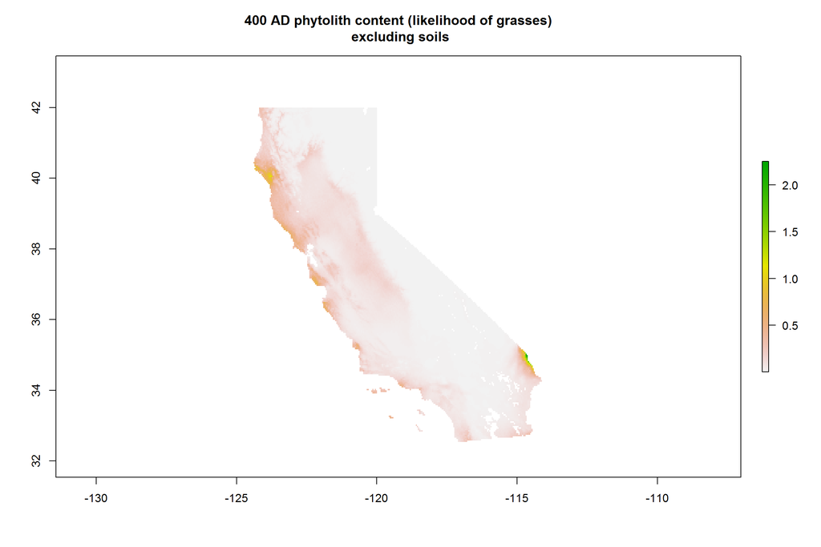

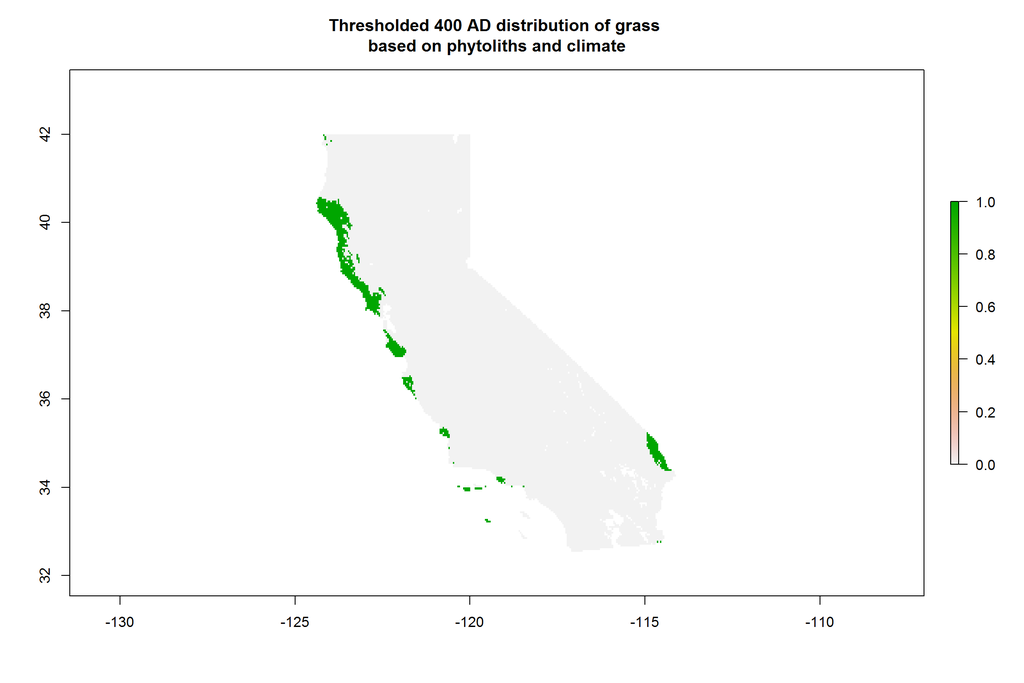

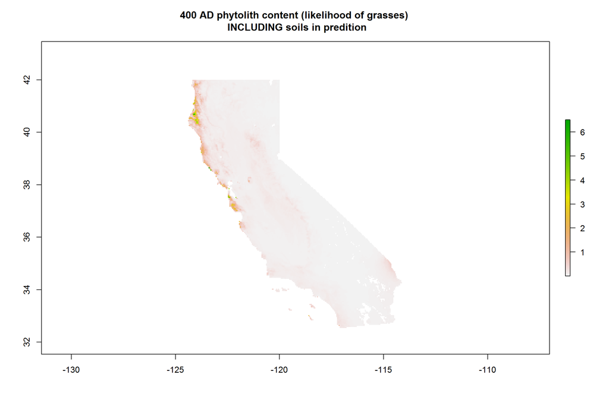

### Change in suitability, using climate of today and model of 400 AD

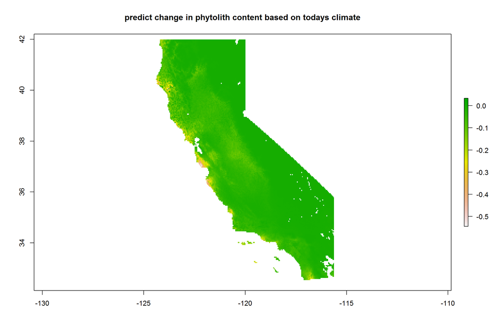

The coasts appear to have become less favorable, perhaps due to hotter/drier conditions there? (double check gcm predictions)

## interpretations

Based on the fitted model for OLS, Here are the important variables (as determinted by stepwise AIC) for the response…

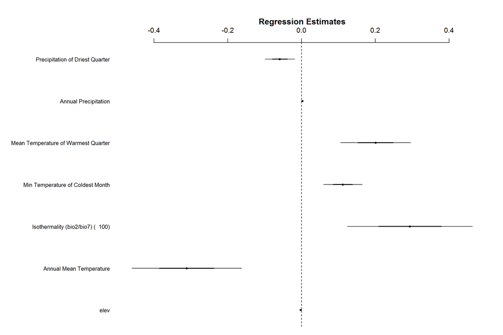

Here is the same, but including soil predictors

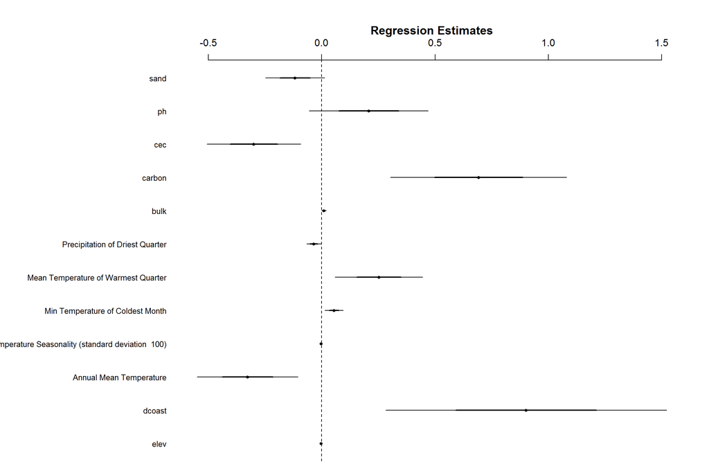

There is clearly a positive relationship with soil carbon, as well as a few other variables.

# Conclusions

- As concluded in Evett and Bartolome 2013, there is little evidence for much pre-historic grass occupation in the central valley *given this phytolith dataset* and *assumptions about the connection between phytolith content and grass occupation*
- Models fit using projected pre-historic climate predict a general decrease in favorability for grasses under current climates, especially on the coast. I need to figure out what change is driving this
- When soils are added as covariates, there tend to be some significant relationships with phytolith content.

# Improvements

- Generate a dataset of *current* native grass distributions throughout the state and see how these compare with phytolith projections
- better analysis of relative importance measures for different covariates
- use ensemble model for predictions.